# MAD – Data Analysis & Biostatistics in R

23 October 2020

[figure not shown]

## Analysis of Variance - 2

## Concepts

- Focus on differences in group means
  - As opposed to regression
- Balanced vs. Unbalanced Models
  - Same number of cases per group (balanced)
  - Different number of cases per group (unbalanced)
- Multiple ANOVA model schemes
  - Class 6: One-Way ANOVA
  - Today: that + Two-Way ANOVA
- Multiple Comparisons
  - Class 6: Bonferroni, Benjamini-Hochberg(BH)
  - Today: Tukey’s HSD
- Use some functions today from `car` package

## Load Data

```r
clin_trial <- read_rds(here("covid_clin_trial_unbal.rds")) %>%
  mutate(drug = factor(drug),
         o2 = factor(o2))
str(clin_trial)
```

```
## tibble [72 x 4] (S3: tbl_df/tbl/data.frame)
##  $ pac_id: chr [1:72] "1" "2" "3" "4" ...
##  $ drug  : Factor w/ 3 levels "hcq","nontussis",..: 3 3 3 3 3 3 3 3 3 3 ...
##  $ o2    : Factor w/ 2 levels "no_supp","supp": 2 2 2 2 2 2 2 2 2 2 ...
##  $ score : num [1:72] 1.8 3.1 7.3 4.7 7.7 6.4 2.6 1.4 4.7 5.9 ...
```

## Table of the Data

```r
clin_trial %>%
  group_by(drug, o2) %>%
  summarise(avg_score = mean(score),
            n = n())
```

```
## # A tibble: 6 x 4
## # Groups:   drug [3]
##   drug      o2      avg_score     n
##   <fct>     <fct>       <dbl> <int>
## 1 hcq       no_supp      4.61    15
## 2 hcq       supp         4.4     11
## 3 nontussis no_supp      6.19    13
## 4 nontussis supp         5.98    11
## 5 placebo   no_supp      4.31    11
## 6 placebo   supp         4.51    11
```

## Descriptive Stat – Supplemental Oxygen

```r
d1 <- clin_trial %>%
  filter(o2 == "supp") %>%
  group_by(drug, o2) %>%
  descr(stats = c("mean", "sd", "min", "med", "max", "iqr", "cv"),
      transpose = TRUE)
```

```
## Descriptive Statistics
## clin_trial$score
## Group: drug = hcq, o2 = supp
## N: 11
##
##               Mean   Std.Dev    Min   Median    Max    IQR     CV
## ----------- ------ --------- ------ -------- ------ ------ ------
##       score   4.40      2.53   1.30     4.70   8.50   4.65   0.58
##
## Group: drug = nontussis, o2 = supp
## N: 11
##
##               Mean   Std.Dev    Min   Median    Max    IQR     CV
## ----------- ------ --------- ------ -------- ------ ------ ------
##       score   5.98      2.29   2.80     5.90   9.20   3.70   0.38
##
## Group: drug = placebo, o2 = supp
## N: 11
##
##               Mean   Std.Dev    Min   Median    Max    IQR     CV
## ----------- ------ --------- ------ -------- ------ ------ ------
##       score   4.51      2.16   1.40     4.70   7.70   3.30   0.48
```

## Descriptive Stat – No Supplemental Oxygen

```r
d2 <- clin_trial %>%
  filter(o2 == "no_supp") %>%
  group_by(drug, o2) %>%
descr(stats = c("mean", "sd", "min", "med", "max", "iqr", "cv"),
      transpose = TRUE)
```

```
## Descriptive Statistics
## clin_trial$score
## Group: drug = hcq, o2 = no_supp
## N: 15
##
##               Mean   Std.Dev    Min   Median    Max    IQR     CV
## ----------- ------ --------- ------ -------- ------ ------ ------
##       score   4.61      1.77   2.00     4.30   8.30   2.25   0.38
##
## Group: drug = nontussis, o2 = no_supp
## N: 13
##
##               Mean   Std.Dev    Min   Median    Max    IQR     CV
## ----------- ------ --------- ------ -------- ------ ------ ------
##       score   6.19      1.98   3.10     6.10   8.50   3.50   0.32
##
## Group: drug = placebo, o2 = no_supp
## N: 11
##
##               Mean   Std.Dev    Min   Median    Max    IQR     CV
## ----------- ------ --------- ------ -------- ------ ------ ------
##       score   4.31      1.69   2.00     4.10   7.20   1.80   0.39
```

## Graph of Data

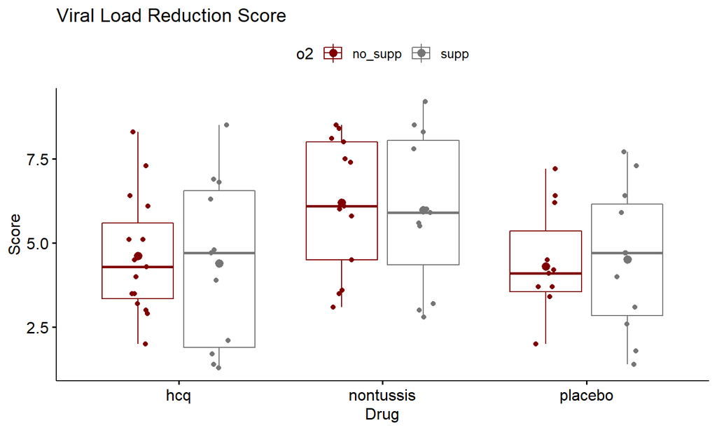

## Graph of Viral Load Reduction Score Errors - Code

```r
gg_error <- clin_trial %>%
  group_by(drug) %>%
  summarise(mean = mean(score),
            sd = sd(score),
            se = sqrt(sd(score)/n())) %>%
  ggplot(aes(x = drug, y = mean)) +
  geom_line() +
  geom_point(size = 4) +
  geom_errorbar(aes(ymin = mean - se, ymax = mean + se), width = .2) +
  labs(title = "Errors by Drug by Suppmental Oxygen", y = "Score", x = "")
```

## Graph

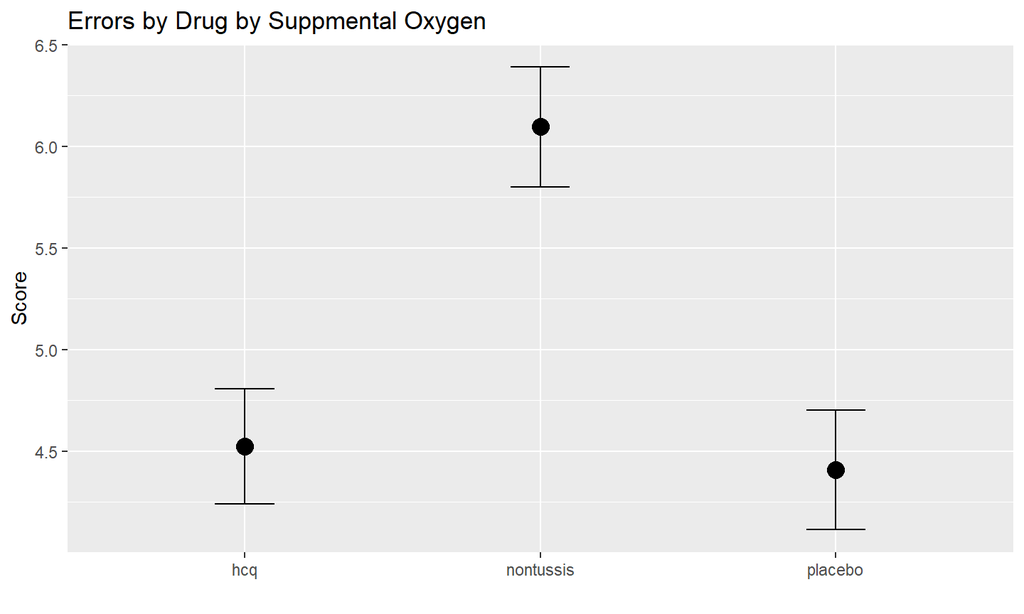

## Graphic Depiction of Variability within and between Groups

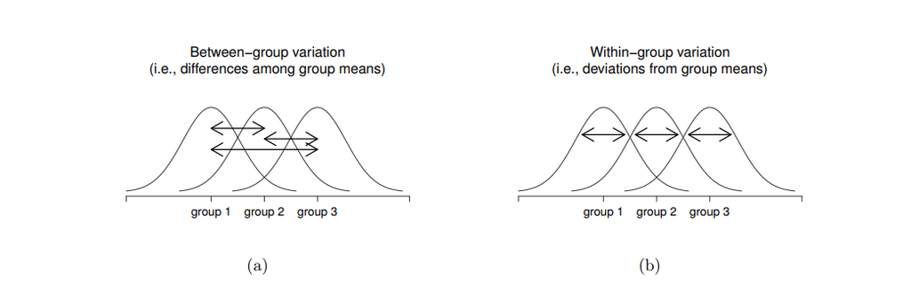

## One-Way ANOVA

- Focus on drug as factor variable
- Two ways to execute in R
  - `aov()` + `summary()` of model
  - `oneway.test()` - only for one-way ANOVA
- Check assumptions 1st
  - Equality of variances among groups:
    - `car::leveneTest()`
  - Normality of residuals
    - `shapiro.test()`
    - QQ-plot of residuals
    - Needs a calculated ANOVA model to have residuals

## Check Equality of Variance Assumption

```r
car::leveneTest(score ~ drug, data = clin_trial, center = mean)
```

```
## Levene's Test for Homogeneity of Variance (center = mean)
##       Df F value Pr(>F)
## group  2  0.1928 0.8251
##       69
```

- \(H_0\) that variances are more or less equal not rejected - OK!

## Normality of Residuals Test - Shapiro-Wilk Test

```r
aov1 <- aov(score ~ drug, data = clin_trial)
shapiro.test(aov1$residuals)
```

```
##
##  Shapiro-Wilk normality test
##
## data:  aov1$residuals
## W = 0.95769, p-value = 0.01639
```

## One-Way ANOVA with `aov()`

```r
aov1 <- aov(score ~ drug, data = clin_trial)
aov1
```

```
## Call:
##    aov(formula = score ~ drug, data = clin_trial)
##
## Terms:
##                      drug Residuals
## Sum of Squares   42.40483 283.37392
## Deg. of Freedom         2        69
##
## Residual standard error: 2.026541
## Estimated effects may be unbalanced
```

## Summary

```r
summary(aov1)
```

```
##             Df Sum Sq Mean Sq F value  Pr(>F)
## drug         2   42.4  21.202   5.163 0.00814 **
## Residuals   69  283.4   4.107
## ---
## Signif. codes:  0 '***' 0.001 '**' 0.01 '*' 0.05 '.' 0.1 ' ' 1
```

## One-Way ANOVA with `oneway.test()`

```r
aov2 <- oneway.test(score ~ drug, data = clin_trial, var.equal = TRUE)
aov2
```

```
##
##  One-way analysis of means
##
## data:  score and drug
## F = 5.1627, num df = 2, denom df = 69, p-value = 0.008139
```

- If the variances are equal, need to use argument `var.equal = TRUE`
- Calculation `oneway.test()` assumes **un**equal variances

## Multiple Comparisons

## Why Do We Need Corrections?

- I explained that when we do multiple tests
  - Elevated chance of having a at least p-value < \(\alpha\) by chance
- If \(\alpha\) = 0.05 and 3 tests (as in this problem), at least 14% prob
  - If number of tests rises to 50 – at least a 92% prob of a significant result by chance

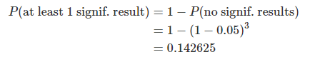

## New Correction - Tukey’s HSD

- Tukey’s Honest Significant Difference
- Uses as input the `aov()` model
- Works for balanced and mildly unbalanced designs
- In base R, so has history and popularity (long time available)

## Executing Tukey’s HSD

```r
TukeyHSD(aov1)
```

```
##   Tukey multiple comparisons of means
##     95% family-wise confidence level
##
## Fit: aov(formula = score ~ drug, data = clin_trial)
##
## $drug
##                        diff        lwr        upr     p adj
## nontussis-hcq      1.572756  0.1986822  2.9468306 0.0209759
## placebo-hcq       -0.113986 -1.5201633  1.2921913 0.9794369
## placebo-nontussis -1.686742 -3.1195221 -0.2539627 0.0170271
```

## Benjamini-Hochberg for Comparison

```r
pairwise.t.test(clin_trial$score, clin_trial$drug, p.adjust.method = "BH")
```

```
##
##  Pairwise comparisons using t tests with pooled SD
##
## data:  clin_trial$score and clin_trial$drug
##
##           hcq   nontussis
## nontussis 0.012 -
## placebo   0.847 0.012
##
## P value adjustment method: BH
```

## Boxplot with the p-Values Shown

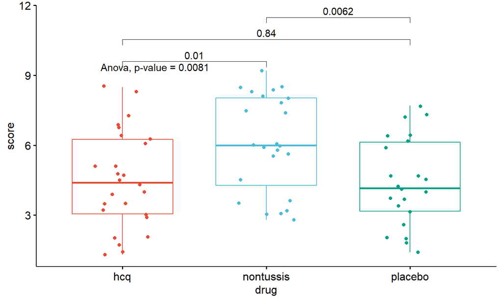

## Two-Way ANOVA

## What is Different from One-Way?

- Adding a second factor to be analyzed together
  - Here supplemental oxygen: `o2`
- Equivalent to multiple linear regression with two covariates
- Can also have interactions between the covariates

## Visualize Differences for Supplemental Oxygen

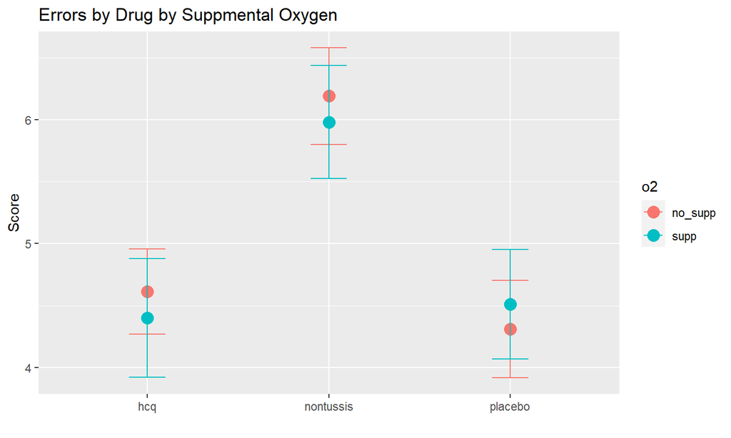

```r
gg_two_way <- clin_trial %>%
  group_by(drug, o2) %>%
  summarise(mean = mean(score),
            sd = sd(score),
            se = sqrt(sd(score)/n())) %>%
  ggplot(aes(x = drug, y = mean, color = o2)) +
  geom_line() +
  geom_point(size = 4) +
  geom_errorbar(aes(ymin = mean - se, ymax = mean + se), width = .2) +
  labs(title = "Errors by Drug by Suppmental Oxygen", y = "Score", x = "")
```

## Prepare *Additive* Model

- Means no interaction Term

```r
aov3 <- aov(score ~ drug + o2, data = clin_trial)
summary(aov3)
```

```
##             Df Sum Sq Mean Sq F value  Pr(>F)
## drug         2  42.40  21.202   5.090 0.00871 **
## o2           1   0.13   0.128   0.031 0.86151
## Residuals   68 283.25   4.165
## ---
## Signif. codes:  0 '***' 0.001 '**' 0.01 '*' 0.05 '.' 0.1 ' ' 1
```

## Comments on ANOVA

- `aov()` internally handles unbalanced models
- If residuals very not normal, use `kruskal.test()` (Kruskal-Wallis test)
- `oneway.test()` does not produce a model object that multiple comparisons can use
- `oneway.test()` assumes model variables **do not** have equal variance
  - Must specify if they do

[figure not shown]